# Environments

### 1.8.3 Namespaces

In the diagram above, you saw that the parent environment of a package varies based on what other packages have been loaded. This seems worrying: doesn’t that mean that the package will find different functions if packages are loaded in a different order? The goal of namespaces is to make sure that this does not happen, and that every package works the same way regardless of what packages are attached by the user.

For example, take `sd()`:

```r
sd
```

```
## function (x, na.rm = FALSE)
## sqrt(var(if (is.vector(x) || is.factor(x)) x else as.double(x),
##     na.rm = na.rm))
## <bytecode: 0x0000000016580360>
## <environment: namespace:stats>
```

`sd()` is defined in terms of `var()`, so you might worry that the result of `sd()` would be affected by any function called `var()` either in the global environment, or in one of the other attached packages.

R avoids this problem by taking advantage of the function (used for lexical scoping) vs. binding environment described above. Every function in a package is associated with a pair of environments: the package environment, which you learned about earlier, and the namespace environment.

- The package environment is the external interface to the package. It’s how you, the R user, find a function in an attached package or with `::`. Its parent is determined by search path, i.e. the order in which packages have been attached.(Binding environment)
- The namespace environment is the internal interface to the package. The package environment controls how we find the function; the namespace controls how the function finds its variables.(Enclosing/function environment)

Every binding in the package environment is also found in the namespace environment; this ensures every function can use every other function in the package. But some bindings only occur in the namespace environment. These are known as internal or non-exported objects, which make it possible to hide internal implementation details from the user.

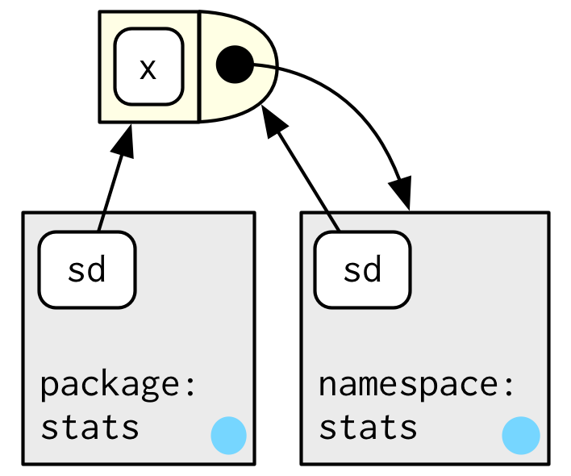

`sd` is bound in both the `package:stats` and `namespace:stats` environments, but `sd()` binds the `namespace:stats` environment.

Every namespace environment has the same set of ancestors:

- Each namespace has an **imports** environment that contains bindings to all the functions used by the package. The imports environment is controlled by the package developer with the `NAMESPACE` file.
- Explicitly importing every base function would be tiresome, so the parent of the imports environment is the base namespace. The base namespace contains the same bindings as the base environment, but it has different parent.
- The parent of the base namespace is the global environment. This means that if a binding isn’t defined in the imports environment the packge will look for it in the usual way. This is usually a bad idea (because it makes code depend on other loaded packages), so `R CMD check` automatically warns about such code. It is needed primarily for historical reasons, particularly due to how S3 method dispatch works

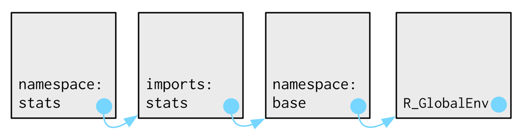

Putting all these diagrams together we get:

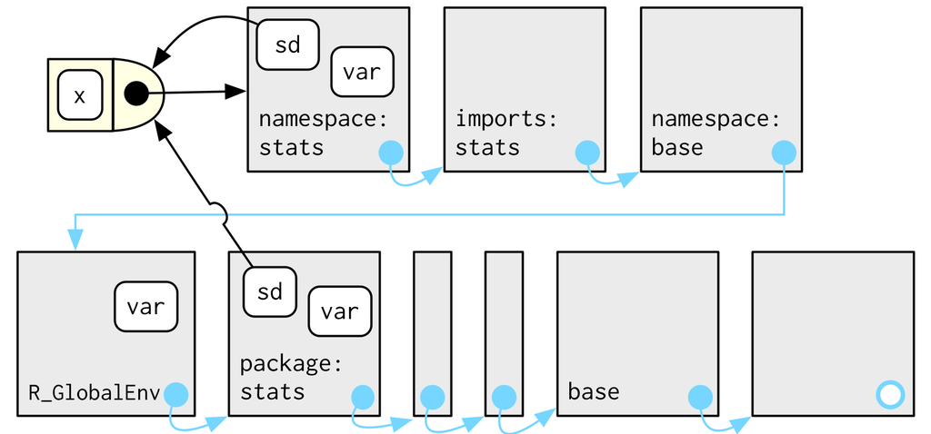

Note that there’s no direct link between the package and namespace environments; the link is defined by the function environments.

#### 1.8.3.1 Don’t do this!

But consider this, in which we also change the enclosing environment of the copied `sd()` to the global environment!!

```r
environment(sd)
```

```
## <environment: namespace:stats>
```

```r
find("sd")
```

```
## [1] "package:stats"
```

```r
sd(1:3)
```

```
## [1] 1
```

```r
environment(sd) <- globalenv()
environment(sd)  # enclosing environment
```

```
## <environment: R_GlobalEnv>
```

```r
find("sd")  # find the binding environment
```

```
## [1] ".GlobalEnv"    "package:stats"
```

```r
globalenv()$sd(1:3)  # or just sd() as global env is first in search path
```

```
## [1] 1
```

```r
# sd() uses var() - redefine var in the global environment!  This is hackish
# and dangerouus!
var <- function(x, na.rm = TRUE) 100
globalenv()$sd(1:3)
```

```
## [1] 10
```

```r
stats::sd(1:3)
```

```
## [1] 1
```

```r
rm(var)
rm(sd)
environment(sd)
```

```
## <environment: namespace:stats>
```

See https://stackoverflow.com/questions/44427752/distinct-enclosing-environment-function-environment-etc-in-r for some good information.

https://rstudio-pubs-static.s3.amazonaws.com/278710_bb8897865caf43c6a39757278547b1f4.html

### 1.8.4 Execution environments

What will the following function return the first time it’s run? What about the second?

```r
g <- function(x) {
    if (!env_has(current_env(), "a")) {
        message("Defining a")
        a <- 1
    } else {
        a <- a + 1
    }
    a
}

g(10)
```

```
## Defining a
```

```
## [1] 1
```

```r
g(10)
```

```
## Defining a
```

```
## [1] 1
```

This function returns the same value every time because of the fresh start principle. Each time a function is called, a new environment is created to host execution. This is called the execution environment, and its parent is the function (enclosing) environment.

For example:

```r
h <- function(x) {
    # 1.
    a <- 2  # 2.
    x + a
}
y <- h(1)  # 3.
```

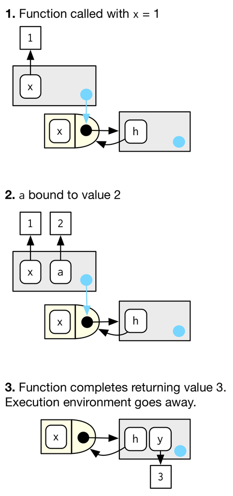

- **Step 1**: Top left box is the execution environment, the bottom right is the enclosing environment.`x` is bound in the execution environment.
- **Step 2**: `a` is bound to the object/value `2` in the execution environment.
- **Step 3**: Function completes and `y` in the ?TJC calling? environment is assigned `3`.

The execution environment is usually ephemeral; once the function has completed, the environment will be GC’d. There are several ways to make it stay around for longer. The first is to explicitly return it:

```r
h2 <- function(x) {
    a <- x * 2
    current_env()  # or parent.frame
}

e <- h2(x = 10)
env_print(e)
```

```
## <environment: 0000000019D088B0>
##   parent: <environment: global>
##   bindings:
##    * a: <dbl>
##    * x: <promise>
```

```r
fn_env(h2)
```

```
## <environment: R_GlobalEnv>
```

Another way to capture it is to return an object with a binding to that environment, like a function. The following example illustrates that idea with a function factory, `plus()`. We use that factory to create a function called `plus_one()`.

```r
plus <- function(x) {
    function(y) x + y
}

plus_one <- plus(1)
plus_one
```

```
## function(y) x + y
## <environment: 0x0000000014ecf7b8>
```

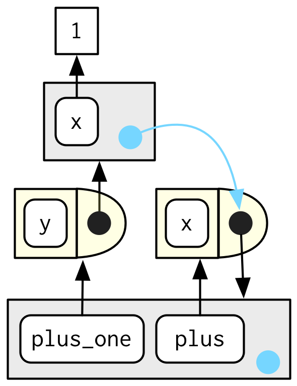

`plus_one` binds the execution environment of `plus`. Hence when we call `plus_one()`, its execution environment will have this captured execution environment of plus() as its parent:

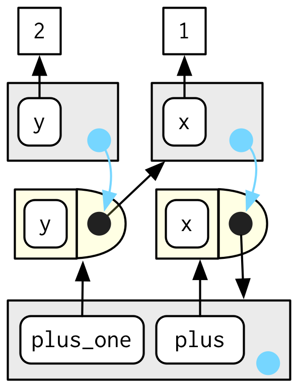

### 1.8.5 Exercises

1. How is `search_envs()` different to `env_parents(global_env())`?  
   **A**: `search_envs()` is not defined in rlang version 0.2.0.9001.
2. Draw a diagram that shows the enclosing environments of this function:

```r
f1 <- function(x1) {
    f2 <- function(x2) {
        f3 <- function(x3) {
            x1 + x2 + x3
        }
        f3(3)
    }
    f2(2)
}
f1(1)
```

```
## [1] 6
```

**A**: TJC

3. Write an enhanced version of `str()` that provides more information about functions. Show where the function was found and what environment it was defined in.  
   **A**: TJC

## 1.9 The call stack

There is one last environment we need to explain, the **caller** environment, accessed with `parent.frame()` or `rlang::caller_env()`. This provides the environment from which the function was called, and hence varies based on how the function is called, not how the function was created.

To fully understand the caller environment we need to discuss two related concepts: the **call stack**, which is made up of **frames**. Executing a function creates two types of context. You’ve learn about one already: the execution environment is a child of the function (enclosing) environment, which is determined by where the function was created. There’s another type of context created by where the function was called: this is called the call stack.

Let’s illustrate this with a simple sequence of calls: f() calls g() calls h().

```r
f <- function(x) {
    g(x = 2)
}
g <- function(x) {
    h(x = 3)
}
h <- function(x) {
    stop()
}
```

The way you most commonly see a call stack in R is by looking at the `traceback()` after an error has occured:

```r
f(x = 1)
traceback()

## Error in h(x = 3)

## 4: stop() at #2

## 3: h(x = 3) at #2

## 2: g(x = 2) at #2

## 1: f(x = 1)
```

Instead of `stop()` `+` `traceback()` to understand the call stack, we’re going to use `lobstr::cst()` to print out the **c**all **s**tack **t**ree:

```r
h <- function(x) {
    lobstr::cst()
}
f(x = 1)
```

```
## x
## \-f(x = 1)
##   \-g(x = 2)
##     \-h(x = 3)
##       \-lobstr::cst()
```

### 1.9.1 Lazy evaluation

The call stack above is simple - while you get a hint that there’s some tree-like structure involved, everything happens on a single branch. This is typical of a call stack when all arguments are eagerly evaluated.

Let’s create a more complicated example that involves some lazy evaluation. We’ll create a sequence of functions, `a()`, `b()`, `c()`, that pass along an argument `x`.

```r
a <- function(x) b(x)
b <- function(x) c(x)
c <- function(x) x

a(f())
```

```
## x
## +-a(f())
## | \-b(x)
## |   \-c(x)
## \-f()
##   \-g(x = 2)
##     \-h(x = 3)
##       \-lobstr::cst()
```

`x` is lazily evaluated so this tree gets two branches. In the first branch `a()` calls `b()`, then `b()` calls `c()`. The second branch starts when `c()` evaluates its argument `x`. This argument is evaluated in a new branch because the environment in which it is evaluated is the global environment, not the environment of `c()`.

### 1.9.2 Frames

Each element of the call stack is a frame, also known as an evaluation context. A frame has three main components that are accessible from R:

- An expression (labelled with `expr`) giving the function call. This is what `traceback()` prints out.
- An environment (labelled with `env`), which is typically the execution environment of a funtion. There are two main exceptions: the environment of the global frame is the global environment, and calling `eval()` also generates frames, where the environment can be anything.
- A parent, the previous call in the call stack (shown by a grey arrow).

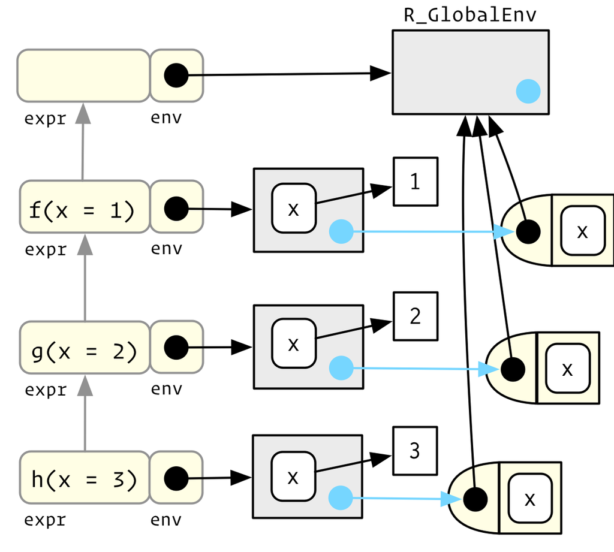

To focus on the calling environments, I have omitted the bindings in the global environment from `f`, `g`, and `h` to the respective function objects.)

The frame also holds exit handlers created with `on.exit()`, restarts and handlers for the the condition system, and which context to `return()` to when a function completes. These are important for the internal operation of R, but are not directly accessible.

Consider this function structure:

```r
f <- function() {
    g <- function(x) {
    }
    g()
}

f()
```

[figure not shown]

```r
f <- function() {
    print("f")
    print(parent.frame())
    print(sys.nframe())
    print(sys.frame(sys.nframe()))
    print(environment())
    print(sys.parent())
    print(sys.call())
    print(sys.on.exit())
    g <- function(x) {
        cat("\ng\n")
        print(parent.frame())
        print(sys.nframe())
        print(sys.frame(sys.nframe()))
        print(environment())
        print(sys.parent())
        print(sys.call())
        print(sys.on.exit())
        cat("\n")
        lobstr::cst()
    }
    g()
}

f()
```

```
[1] "f"
<environment: R_GlobalEnv>
[1] 1
<environment: 0x000000001684fcc0>
<environment: 0x000000001684fcc0>
[1] 0
f()
NULL

g<environment: 0x000000001684fcc0>
[1] 2
<environment: 0x000000001680ab58>
<environment: 0x000000001680ab58>
[1] 1
g()
NULL

x
\-f()
  \-g()
    \-lobstr::cst()
```

### 1.9.3 Dynamic scoping

Looking up variables in the calling stack rather than in the enclosing environment is called dynamic scoping. Few languages implement dynamic scoping because dynamic scoping makes it much harder to reason about how a function operates: not only do you need to know how it was defined, you also need to know the context in which it was called. Dynamic scoping is primarily useful for developing functions that aid interactive data analysis. It is one of the topics discussed in non-standard evaluation.

### 1.9.4 Exercises

1. Write a function that lists all the variables defined in the environment in which it was called. It should return the same results as `ls()`.

**A**:

````
```r
x <- 1
ls_call <- function() {
    y <- 1
    print(ls())
    ls(parent.frame())
}
ls()
ls_call()
```

```
> ls()
[1] "ls_call" "x"
> ls_call()
[1] "y"
[1] "ls_call" "x"
```
````

### 1.9.5 As data structures

As well as powering scoping, environments are also useful data structures in their own right because they have reference semantics. There are three common problems that they can help solve:

- Avoiding copies of large data. Since environments have reference semantics, you’ll never accidentally create a copy. This makes it a useful vessel for large objects. Bare environments are not that pleasant to work with; I recommend using R6 objects instead.
- Managing state within a package. Explicit environments are useful in packages because they allow you to maintain state across function calls. Normally, objects in a package are locked, so you can’t modify them directly. Instead, you can do something like this:

  ```r
  my_env <- new.env(parent = emptyenv())
  my_env$a <- 1

  get_a <- function() {
      my_env$a
  }
  set_a <- function(value) {
      old <- my_env$a
      my_env$a <- value
      invisible(old)
  }
  ```

  Returning the old value from setter functions is a good pattern because it makes it easier to reset the previous value in conjunction with `on.exit()`.
- As a hashmap. A hashmap is a data structure that takes constant, O(1), time to find an object based on its name. Environments provide this behaviour by default, so can be used to simulate a hashmap.

### 1.9.6 `<<-`

The ancestors of an environment have an important relationship to `<<-`. The regular assignment arrow, `<-`, always creates a variable in the current environment. The deep assignment arrow, `<<-`, never creates a variable in the current environment, but instead modifies an existing variable found by walking up the parent environments.

```r
x <- 0
f <- function() {
    x <<- 1
}
f()
x
```

```
## [1] 1
```

If `<<-` doesn’t find an existing variable, it will create one in the global environment. This is usually undesirable, because global variables introduce non-obvious dependencies between functions. `<<-` is most often used in conjunction with a closure.

### 1.9.7 Exercises

1. What does this function do? How does it differ from `<<-` and why might you prefer it?

```r
rebind <- function(name, value, env = caller_env()) {
    if (identical(env, empty_env())) {
        stop("Can't find `", name, "`", call. = FALSE)
    } else if (env_has(env, name)) {
        env_poke(env, name, value)
    } else {
        rebind(name, value, env_parent(env))
    }
}
rebind("a", 10)
a <- 5
rebind("a", 10)
a
```

```
## [1] 10
```

**A**: Same as `<<-` except does not create a variable in the global environment if not found beforehand.

### 1.9.8 Resources

https://stackoverflow.com/questions/7903414/how-are-environments-enclosures-and-frames-related https://www.r-bloggers.com/using-closures-as-objects-in-r/